# Supervised Learning - Foundations Project: ReCell

Everyone likes a good camera to capture their favorite moments with loved ones. Some customers specifically look for good front cameras to click cool selfies. Let's create a new dataframe of only those devices which are suitable for this customer segment with greater than 8MP and analyze.

```python
# creating data frame of phones with selfie camera size greater than 8MP
df_selfie_camera = df[df.selfie_camera_mp > 8]
df_selfie_camera.shape
```

```
(655, 15)
```

Observations: The data set of used phones with selfie camera size greater than 8MP has 15 attributes and 655 rows

```python
df_selfie_camera = df[df.selfie_camera_mp > 8]
df_selfie_camera.head(5)
```

|  | brand_name | os | screen_size | 4g | 5g | main_camera_mp | selfie_camera_mp | int_memory | ram | battery | weight | release_year | days_used | normalized_used_price | normalized_new_price |
| --- | --- | --- | --- | --- | --- | --- | --- | --- | --- | --- | --- | --- | --- | --- | --- |
| 1 | Honor | Android | 17.30 | yes | yes | 13.0 | 16.0 | 128.0 | 8.0 | 4300.0 | 213.0 | 2020 | 325 | 5.162097 | 5.519018 |
| 8 | Honor | Android | 15.32 | yes | no | 13.0 | 16.0 | 128.0 | 6.0 | 4000.0 | 165.0 | 2020 | 161 | 4.886054 | 5.299916 |
| 12 | Honor | Android | 16.69 | yes | yes | 13.0 | 16.0 | 128.0 | 8.0 | 4100.0 | 206.0 | 2019 | 537 | 5.383256 | 6.213968 |
| 13 | Honor | Android | 15.32 | yes | no | 13.0 | 16.0 | 64.0 | 4.0 | 4000.0 | 171.5 | 2019 | 336 | 4.617593 | 5.398751 |
| 16 | Honor | Android | 15.90 | yes | no | 13.0 | 32.0 | 128.0 | 6.0 | 3750.0 | 172.0 | 2019 | 395 | 5.022366 | 5.517935 |

Observations: Data of first 5 rows of the new data set

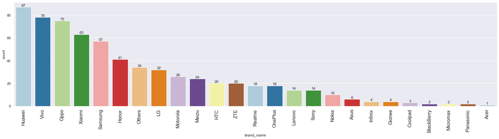

```python
## create labeled_barplot for 'brand_name' in high selfie camera dataframe
labeled_barplot(df_selfie_camera, "brand_name")
```

The distribution of used phones with a selfie greater than 8MP varied across brands with Huawei and Vivi having the highest number of used devices

Observations: Rear cameras generally have a better resolution than front cameras, so we set the threshold higher for them at 16MP.

```python
# creating main camera dataframe with a higher resolution than 16MP
df_main_camera = df[df.main_camera_mp > 16]
df_main_camera.shape
```

```
(94, 15)
```

Observations: The dataframe with main camera higher than 16MP has 15 atributes and 94 rows

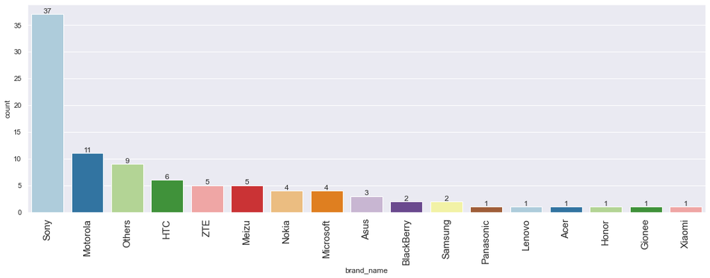

```python
## creating labeled_barplot for 'brand_name' in high main camera dataframe
labeled_barplot(df_main_camera, "brand_name")
```

The distribution of used devices with high resolution main camera size greater than 16Mp varied across brands Fewer phone brands had devices with main camera greater than 16 Sony had the highest number of phones followed by motorola with main camera sizes gfreater than 16Observations: Price of used devices varies across the years.

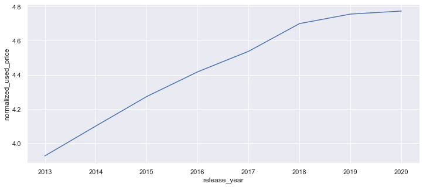

```python
## Creating a lineplot for release year and used price
import seaborn as sns
import matplotlib.pyplot as plt
plt.figure(figsize=(12, 5))
sns.lineplot(data=df, x="release_year", y="normalized_used_price", ci=None)
plt.show()
```

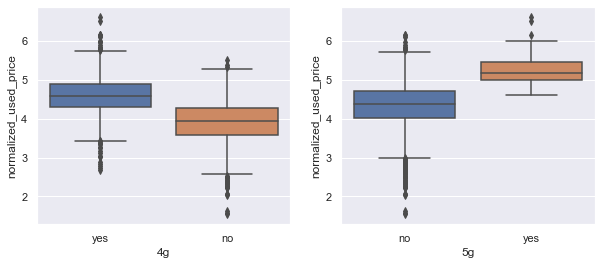

```python
# Box plots offering 4G and 5G networks
plt.figure(figsize=(10, 4))

plt.subplot(121)
sns.boxplot(data=df, x="4g", y="normalized_used_price")

plt.subplot(122)
sns.boxplot(data=df, x="5g", y="normalized_used_price")

plt.show()
```

The median normalised used prices of devices with 4G was generally lower (4.5 euros) comapred to devices with 5G whose median normalised used price was about 5.2 euros Devices without 4G had lowere normalised used price of about 4 euros. The normalised used prices for devices without 5G was higher at about 4.4 euros

## Data Preprocessing

- Missing value treatment
- Feature engineering (if needed)
- Outlier detection and treatment (if needed)
- Preparing data for modeling
- Any other preprocessing steps (if needed)

```python
# Creating a copy of the data
df1 = df.copy()
```

A copy of the df data frame was been created

```python
# checking for missing values

df1.isnull().sum()
```

```
brand_name                 0
os                         0
screen_size                0
4g                         0
5g                         0
main_camera_mp           179
selfie_camera_mp           2
int_memory                 4
ram                        4
battery                    6
weight                     7
release_year               0
days_used                  0
normalized_used_price      0
normalized_new_price       0
dtype: int64
```

Observations: The df1 data frame has missing values: main_camera_mp (179), selfie_camera_mp (2), int_memory (4), ram (4), battery (6) and weight (7).

```python
cols_impute = [
    "main_camera_mp",
    "selfie_camera_mp",
    "int_memory",
    "ram",
    "battery",
    "weight",
]

for col in cols_impute:
    df1[col] = df1[col].fillna(
        value=df1.groupby(['release_year', 'brand_name'])[col].transform("median")
    )   ## Complete the code to impute missing values in cols_impute with median by grouping the data on release year and brand name

# checking for missing values
df1.isnull().sum() ## Complete the code to check missing values after imputing the above columns
```

```
brand_name                 0
os                         0
screen_size                0
4g                         0
5g                         0
main_camera_mp           179
selfie_camera_mp           2
int_memory                 0
ram                        0
battery                    6
weight                     7
release_year               0
days_used                  0
normalized_used_price      0
normalized_new_price       0
dtype: int64
```

```python
cols_impute = [
    "main_camera_mp",
    "selfie_camera_mp",
    "int_memory",
    "ram",
    "battery",
    "weight",
]

for col in cols_impute:
    df1[col] = df1[col].fillna(
        value=df1.groupby(['release_year', 'brand_name'])[col].transform("median")
    )   ## Complete the code to impute missing values in cols_impute with median by grouping the data on release year and brand name

# checking for missing values
df1.isnull().sum() ## Complete the code to check missing values after imputing the above columns
```

```
brand_name                 0
os                         0
screen_size                0
4g                         0
5g                         0
main_camera_mp           179
selfie_camera_mp           2
int_memory                 0
ram                        0
battery                    6
weight                     7
release_year               0
days_used                  0
normalized_used_price      0
normalized_new_price       0
dtype: int64
```

```python
cols_impute = [
    "main_camera_mp",
    "selfie_camera_mp",
    "battery",
    "weight",
]

for col in cols_impute:
    df1[col] = df1[col].fillna(
        value=df1.groupby(['brand_name'])[col].transform("median")
    ) ## Complete the code to impute the missing values in cols_impute with median by grouping the data on brand name

# checking for missing values
df1.isnull().sum() ## Complete the code to check missing values after imputing the above columns
```

```
brand_name                0
os                        0
screen_size               0
4g                        0
5g                        0
main_camera_mp           10
selfie_camera_mp          0
int_memory                0
ram                       0
battery                   0
weight                    0
release_year              0
days_used                 0
normalized_used_price     0
normalized_new_price      0
dtype: int64
```

```python
df1["main_camera_mp"] = df1["main_camera_mp"].fillna(df1["main_camera_mp"].median) ## Complete the code to impute the data with median

# checking for missing values
df1.isnull().sum() ## Complete the code to check missing values after imputing the above columns
```

```
brand_name               0
os                       0
screen_size              0
4g                       0
5g                       0
main_camera_mp           0
selfie_camera_mp         0
int_memory               0
ram                      0
battery                  0
weight                   0
release_year             0
days_used                0
normalized_used_price    0
normalized_new_price     0
dtype: int64
```

Observations: The data frame now has no missing data